# General Linear Blend Frequency Polygon (GLBFP) density estimation

# Introduction

The General Linear Blend Frequency Polygon (GLBFP) method is a powerful tool for nonparametric density estimation. This vignette illustrates how to use the key functions in the `GLBFP` package for local and global density estimation, with detailed examples and visualizations. GLBFP is particularly useful for data that require flexible density estimation techniques.

# Local estimation

In density estimation, the choice of the bin width $b$ is critical. A small $b$ can lead to overfitting (capturing noise rather than structure), while a large $b$ may oversmooth the data, masking important features. The `GLBFP` package provides tools to select an optimal bin width and apply it effectively.

## Optimal value of $b$

To determine the optimal value of $b$, we use the dataset `ashua`, included in the `GLBFP` package, to demonstrate a practical example

```r
library(GLBFP)

# Load the example dataset `ashua` from the package
data("ashua")

df = data.frame(level = ashua$level, log_flow = log(ashua$flow))
head(df)
```

```
#>   level log_flow
#> 1 29.75 3.927896
#> 2 29.68 3.935740
#> 3 29.75 3.935740
#> 4 29.74 3.937691
#> 5 29.73 3.945458
#> 6 29.72 3.943522
```

The optimal $b$ value can be evaluated using the `compute_bi_optim` function:

```r
compute_bi_optim(df, m = c(1,1))
```

```
#>     level  log_flow
#> 0.1731101 0.1805878
```

This function returns the optimal bin width for each dimension of the dataset, which is critical for accurate density estimation.

## Density estimation at local point

### LBFP

```r
b_ashua <- c(0.19, 0.15)  # Bin width for each dimension
x_ashua <- c(round(mean(df$level),2), round(mean(df$log_flow),2)) # single point to evaluate

out <- LBFP(x = x_ashua, data = df, b = b_ashua)
out
```

```
#> LBFP Density Estimation:
#> Point of estimation: (30.42, 5.21)
#> Estimated density: 0.194959
#> Estimated standard error 0.2788765
#> 95% confidence interval: 0.1460876 0.2438304
#> Bandwidths (b): 0.19, 0.15
```

```r
names(out)
```

```
#> [1] "x"          "estimation" "sd"         "IC"         "b"
```

The output is a list containing:

- `estimation`: the density value at `x`.
- `sd`: the standard error.
- `IC`: the 95% confidence interval.
- `b` :the bin width used.

### ASH and GLFBP

Similarly, the user can estimate density at the same point using `ASH` or `GLBFP` functions:

```r
ASH(x_ashua, df, b_ashua)
```

```
#> ASH Density Estimation:
#> Point of estimation: (30.42, 5.21)
#> Estimated density: 0.1518949
#> Bandwidths (b): 0.19, 0.15
#> Shifts (m): 1, 1
```

```r
GLBFP(x_ashua, df, b_ashua)
```

```
#> GLBFP Density Estimation:
#> Point of estimation: (30.42, 5.21)
#> Estimated density: 0.194959
#> Bandwidths (b): 0.19, 0.15
#> Shifts (m): 1, 1
```

### GLBFP

The user can use the `GLBFP` function to estimate the density at `x_ashua` point:

The `GLBFP` function allows flexibility in setting shifts for each dimension, which can refine the estimation further:

```r
GLBFP(x_ashua, df, b_ashua, m = c(5, 8))
```

```
#> GLBFP Density Estimation:
#> Point of estimation: (30.42, 5.21)
#> Estimated density: 0.1927285
#> Bandwidths (b): 0.19, 0.15
#> Shifts (m): 5, 8
```

# Global estimation

Global density estimation evaluates the density across a grid of points. The `*_estimate` functions in the `GLBFP` package simplify this process.

## Using a Grid

Two approaches are available:

- *Automatic Grid*: Specify `grid_size` (default is 20), and the grid spans the range of each dimension.
- *Custom Grid*: Provide specific `grid_points`.

Example with default grid size:

```r
out <- LBFP_estimate(df, b = b_ashua, grid_size = 20) # default is grid_size = 20
out
```

```
#> LBFP Density Estimation on Grid:
#> Grid size: 20
#> Bandwidths (b): 0.19, 0.15
#> Number of estimated densities: 400
```

```r
names(out)
```

```
#> [1] "grid"      "densities" "b"         "grid_size"
```

```r
head(cbind(out$grid, out$densities))
```

```
#>          Var1     Var2
#> [1,] 29.33000 3.676301 0.00000000
#> [2,] 29.53821 3.676301 0.12441252
#> [3,] 29.74642 3.676301 0.01292402
#> [4,] 29.95463 3.676301 0.04597373
#> [5,] 30.16284 3.676301 0.09859105
#> [6,] 30.37105 3.676301 0.00000000
```

Example with a custom grid:

```r
## grid zoomed in mean +- 1*sd

spec_grid <- list(level = seq(mean(df$level)-sd(df$level),mean(df$level)+sd(df$level),length.out = 10),
                   log_flow =                   seq(mean(df$log_flow)-sd(df$log_flow),mean(df$log_flow)+sd(df$log_flow),length.out = 10))
spec_grid
```

```
#> $level
#>  [1] 29.81221 29.94721 30.08220 30.21719 30.35219 30.48718 30.62218 30.75717
#>  [9] 30.89217 31.02716
#>
#> $log_flow
#>  [1] 4.429594 4.603579 4.777564 4.951549 5.125535 5.299520 5.473505 5.647491
#>  [9] 5.821476 5.995461
```

```r
spec_grid_ex <- as.matrix(expand.grid(spec_grid))

out_spec_grid <- LBFP_estimate(df, b = b_ashua, grid_points = spec_grid_ex) # default is grid_size = 20
out_spec_grid
```

```
#> LBFP Density Estimation on Grid:
#> Grid size: 10
#> Bandwidths (b): 0.19, 0.15
#> Number of estimated densities: 100
```

```r
names(out_spec_grid)
```

```
#> [1] "grid"      "densities" "b"         "grid_size"
```

```r
head(cbind(out_spec_grid$grid, out_spec_grid$densities))
```

```
#>         level log_flow
#> [1,] 29.81221 4.429594 0.07340577
#> [2,] 29.94721 4.429594 0.16547569
#> [3,] 30.08220 4.429594 0.34449384
#> [4,] 30.21719 4.429594 0.52926902
#> [5,] 30.35219 4.429594 0.39639885
#> [6,] 30.48718 4.429594 0.04127109
```

For GLBFP, note that the number of evaluations increases with grid size and shift values. The number of ASH evaluation is:

$$gridsize*gridsize* \prod_{i=1}^d (2*m_i)$$

```r
out_GLBFP <- GLBFP::GLBFP_estimate(df, b = b_ashua, m = c(3,3), grid_size = 5) # default is grid_size = 20
out_GLBFP
```

```
#> GLBFP Density Estimation on Grid:
#> Grid size: 5
#> Bandwidths (b): 0.19, 0.15
#> Shifts (m): 3, 3
#> Number of estimated densities: 25
```

```r
names(out_GLBFP)
```

```
#> [1] "grid"      "densities" "b"         "m"         "grid_size"
```

```r
head(cbind(out_GLBFP$grid, out_GLBFP$densities))
```

```
#>        Var1     Var2
#> [1,] 29.330 3.676301 0.0000000000
#> [2,] 30.319 3.676301 0.0208370428
#> [3,] 31.308 3.676301 0.0000000000
#> [4,] 32.297 3.676301 0.0000000000
#> [5,] 33.286 3.676301 0.0000000000
#> [6,] 29.330 4.590481 0.0008042992
```

## Visualization¸

For dimensions $d \leq 2$, the `*_estimate` functions include `plot` methods:

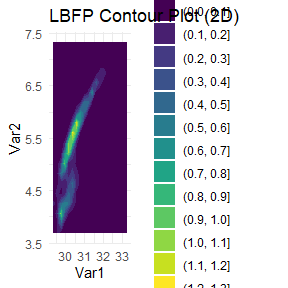

```r
plot(out, contour = TRUE)
```

```r
plot(out, contour = FALSE)
```

[interactive chart not shown]

# Others examples

## Example 1: More Complex Example with Autocorrelation

We simulate autocorrelated data based on a Markov chain scenario to demonstrate the flexibility of the `*_estimate` functions.

```r
library(MASS)  # For generating multivariate normal data

# Define the parameters for the Markov chain
P <- matrix(c(0.7, 0.2, 0.05, 0.05,
              0.15, 0.7, 0.1, 0.05,
              0, 0.15, 0.8, 0.05,
              0.15, 0.05, 0.2, 0.6),
            nrow = 4, byrow = TRUE)

# Stationary distribution
pi_tilde <- c(2/9, 1/3, 1/3, 1/9)

# Means of the bivariate normals
mu_list <- list(c(-1.5, -1.5),
                c(-1.5, 1.5),
                c(1.5, -1.5),
                c(1.5, 1.5))

# Covariance matrices
V1 <- V2 <- matrix(c(0.15, 0.0415, 0.0415, 0.25), nrow = 2)
V3 <- V4 <- matrix(c(0.15, -0.0415, -0.0415, 0.25), nrow = 2)
V_list <- list(V1, V2, V3, V4)

# Number of realizations to generate
n <- 1000

# Initialize vectors to store the results
Y <- numeric(n)
X <- matrix(0, nrow = n, ncol = 2)

# Generate Y0 from the stationary distribution
set.seed(123)  # For reproducibility
Y[1] <- sample(1:4, size = 1, prob = pi_tilde)

# Generate X0 based on Y0
X[1, ] <- mvrnorm(1, mu = mu_list[[Y[1]]], Sigma = V_list[[Y[1]]])

# Generate the Markov chain and bivariate normals
for (t in 2:n) {
  # Generate Y_t based on Y_{t-1}
  Y[t] <- sample(1:4, size = 1, prob = P[Y[t - 1], ])

  # Generate X_t based on Y_t
  X[t, ] <- mvrnorm(1, mu = mu_list[[Y[t]]], Sigma = V_list[[Y[t]]])
}

# Estimate the density across a grid using estimate_LBFP


b <- c(0.075, 0.15)  # Bin width for each dimension
result <- LBFP_estimate(X, b)
result2 <- GLBFP_estimate(X, b , m=c(5,5))
plot(result)
```

[interactive chart not shown]

```r
plot(result2)
```

[interactive chart not shown]

# Conclusion

The `GLBFP`` package provides robust tools for density estimation, both locally and globally. Its flexibility in handling different bin widths and shifts makes it suitable for a wide range of applications.